# Лабораторная работа №4

Адресация IPv4 и IPv6. Двойной стек

Гашимова Эсма Эльшан кызы

1132247520@rudn.ru

Российский университет дружбы народов

2026-10-06

# Цели и задачи работы

## Цель лабораторной работы

Изучение принципов настройки IPv4- и IPv6-адресации в локальных сетях.

Получение навыков настройки двойного стека адресации.

Проверка сетевой связности между устройствами с помощью `ping` и `trace`.

Анализ трафика ARP, ICMP и ICMPv6 в Wireshark.

# Настройка сети с двойным стеком

## Создание топологии

[figure not shown]

Топология сети с IPv4-, IPv6-подсетями и сервером двойного стека

## Настройка PC1

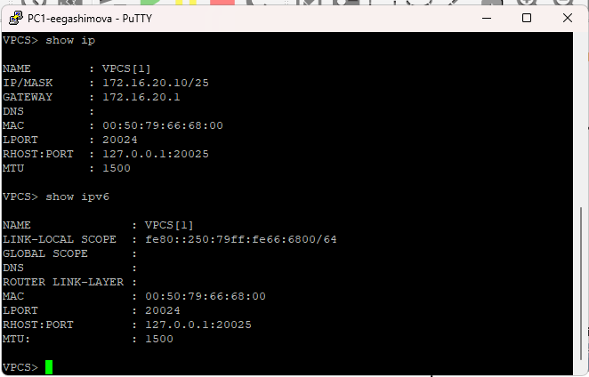

Проверка IPv4- и IPv6-конфигурации PC1

## Настройка PC2

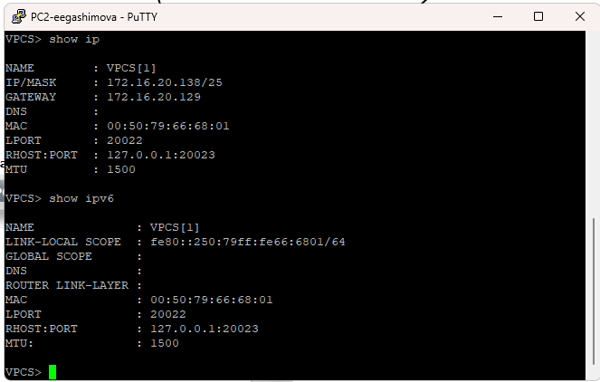

Проверка IPv4- и IPv6-конфигурации PC2

## Настройка сервера IPv4

[figure not shown]

Первоначальная настройка IPv4 на сервере двойного стека

# Настройка маршрутизатора FRR

## Настройка IPv4-интерфейсов FRR

[figure not shown]

Настройка IPv4-адресов интерфейсов маршрутизатора FRR

## Проверка конфигурации FRR

[figure not shown]

Проверка running-config маршрутизатора FRR

## Проверка интерфейсов FRR

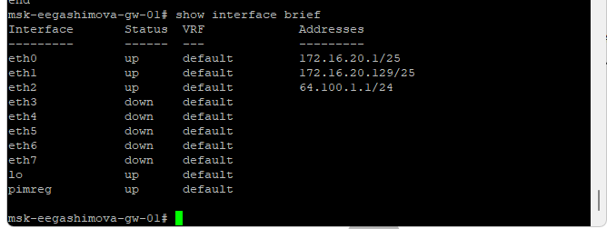

Краткая информация об интерфейсах маршрутизатора FRR

# Проверка IPv4-связности

## Проверка связи с PC1

[figure not shown]

Проверка связи PC1 с PC2 и сервером

## Проверка связи с PC2

[figure not shown]

Проверка связи PC2 с PC1 и сервером

# Настройка IPv6-сети

## Настройка PC3

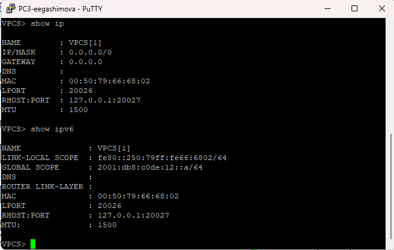

Проверка IPv6-конфигурации PC3

## Настройка PC4

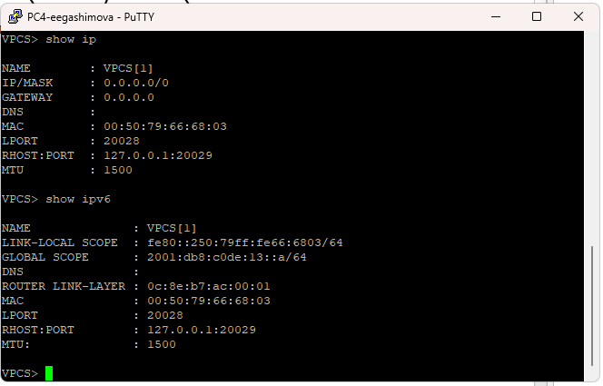

Проверка IPv6-конфигурации PC4

# Настройка маршрутизатора VyOS

## Начальная настройка VyOS

[figure not shown]

Изменение имени VyOS и удаление DHCP с eth0

## Настройка IPv6-интерфейсов VyOS

[figure not shown]

Настройка IPv6-адресов и Router Advertisement на VyOS

## Проверка интерфейсов VyOS

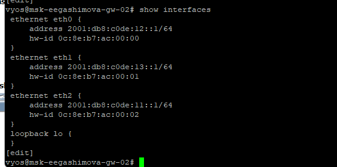

Проверка IPv6-адресов интерфейсов VyOS

# Проверка IPv6-связности

## Проверка связи с PC3

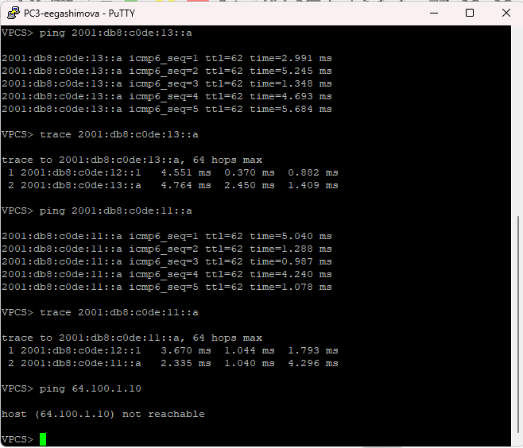

Проверка IPv6-связи с PC3 и отсутствие доступа к IPv4

## Проверка связи с PC4

[figure not shown]

Проверка IPv6-связи с PC4 и недоступность IPv4-узла

## Проверка сервера двойного стека

[figure not shown]

Проверка доступа сервера двойного стека ко всем оконечным устройствам

# Анализ трафика в Wireshark

## Анализ ARP

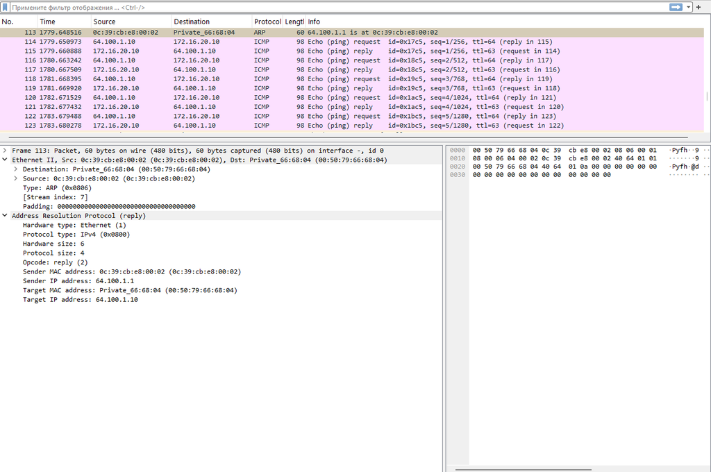

Анализ ARP-пакета на соединении сервера

## Анализ ICMP

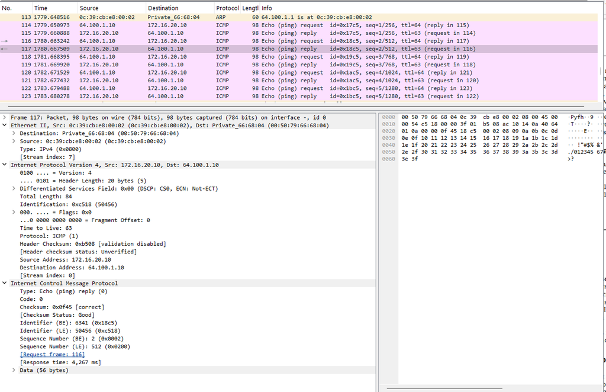

Анализ ICMP Echo Reply между PC1 и сервером

## Анализ ICMPv6

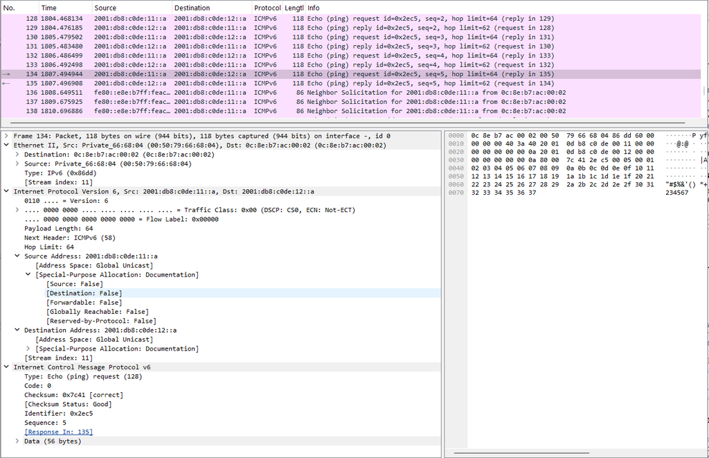

Анализ ICMPv6 и Neighbor Solicitation

# Самостоятельное задание

## Исходные подсети

Для самостоятельного задания заданы две подсети:

`10.10.1.96/27`

`2001:db8:1:1::/64`

и

`10.10.1.16/28`

`2001:db8:1:4::/64`

Для интерфейсов маршрутизатора выбраны минимальные доступные адреса подсетей.

## Таблица адресации

Для первой подсети выбран шлюз:

`10.10.1.97/27`

`2001:db8:1:1::1/64`

Для второй подсети выбран шлюз:

`10.10.1.17/28`

`2001:db8:1:4::1/64`

Оконечные устройства получают адреса из соответствующих подсетей.

## Топология самостоятельного задания

[figure not shown]

Топология сети для самостоятельного задания

## Настройка PC1

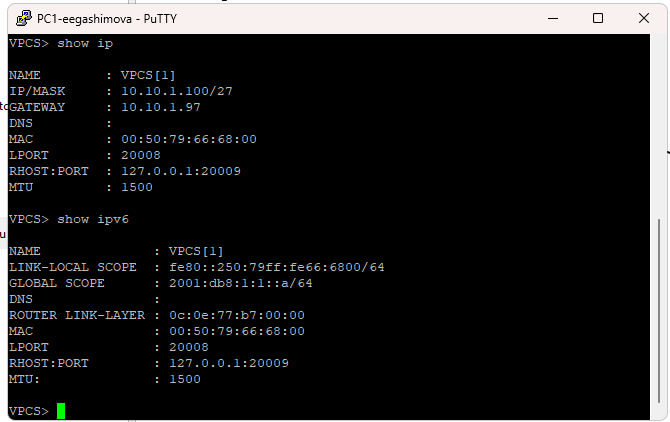

Настройка двойного стека на PC1

## Настройка PC2

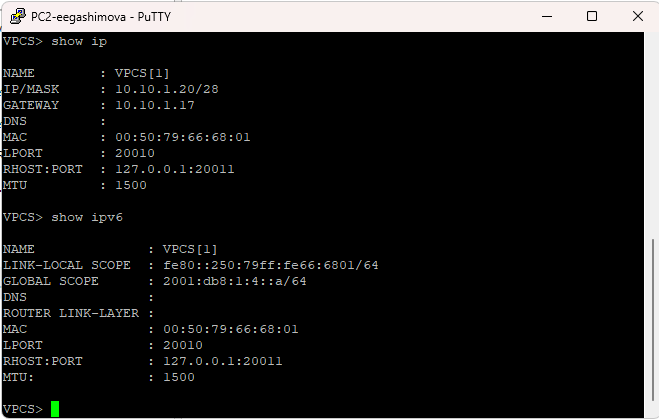

Настройка двойного стека на PC2

## Начальная настройка маршрутизатора

[figure not shown]

Начальная настройка маршрутизатора VyOS

## Настройка интерфейсов маршрутизатора

[figure not shown]

Настройка IPv4 и IPv6 на интерфейсах маршрутизатора

## Проверка интерфейсов

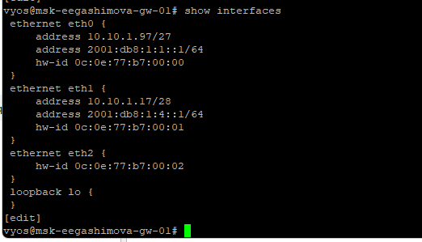

Проверка интерфейсов VyOS в самостоятельном задании

# Проверка самостоятельного задания

## Проверка связи с PC1

[figure not shown]

Проверка IPv4- и IPv6-связи с PC1

## Проверка связи с PC2

[figure not shown]

Проверка IPv4- и IPv6-связи с PC2

# Результаты работы

## Выполненные действия

В GNS3 построена топология сети с IPv4- и IPv6-подсетями.

Настроены маршрутизаторы FRR и VyOS.

Настроены оконечные устройства VPCS.

Проверена связность между узлами с помощью `ping` и `trace`.

Проанализирован трафик ARP, ICMP и ICMPv6 в Wireshark.

## Полученные результаты

IPv4-сеть работает через маршрутизатор FRR.

IPv6-сеть работает через маршрутизатор VyOS.

Сервер двойного стека доступен как по IPv4, так и по IPv6.

Устройства только с IPv4 и только с IPv6 напрямую друг другу недоступны.

Самостоятельная топология успешно настроена с двойным стеком адресации.

## Вывод

В ходе лабораторной работы была настроена сеть с поддержкой IPv4 и IPv6.

Были получены практические навыки настройки адресации на VPCS, FRR и VyOS.

Анализ трафика показал различия между ARP в IPv4 и Neighbor Discovery в IPv6.

Работоспособность созданных топологий подтверждена успешными проверками `ping` и `trace`.